# Practical Machine Learning Course Project

Laura Sedman

16 September 2014

Human activity recognition analyses have usually focused on identifying the type of activity performed. In contrast, the weight lifting exercise dataset [1] can be used to investigate how well an exercise was performed. The dataset consists of data from accelerometers on the belt, forearm, arm, and dumbell of six participants, who were asked to perform barbell lifts correctly and incorreclty in five different ways. More information about the dataset can be found here: http://groupware.les.inf.puc-rio.br/har

The aim of this project was build a model that could predict how well the participants performed the exercise.

The first step was to download and read in the data that I would use to build a prediction model, and a final testing set on which to apply the model.

```r
url1 <- "https://d396qusza40orc.cloudfront.net/predmachlearn/pml-training.csv"
url2 <- "https://d396qusza40orc.cloudfront.net/predmachlearn/pml-testing.csv"

if (!file.exists("pml-training.csv")) {
        download.file(url1, destfile="pml-training.csv", method="curl")
}

if (!file.exists("pml-testing.csv")) {
        download.file(url2, destfile="pml-testing.csv", method="curl")
}

data <- read.csv("pml-training.csv")
finalTesting <- read.csv("pml-testing.csv")
rm(url1, url2)
```

In order to later estimate how well the chosen prediction model would perform on new data, I split the original dataset into a training and test partition, with 13737 and 5885 observations, respectively.

```r
library(caret)
set.seed(27)
inTrain <- createDataPartition(y = data$classe, p=0.7, list=FALSE)
train <- data[inTrain,]
test <- data[-inTrain,]
rm(inTrain)
rm(data)
```

I then explored the training set using the str and summary functions. Because this would output a large amount of text, the results were not displayed here.

```r
str(train)
summary(train)
```

I noticed that several of the 159 variables contain many NAs. Because these variables would not be suitable for building the model, I decided to remove them from the training set as well as both of the test sets. In addition, I removed the variables “X” (observation number) and three timestamp-related variables. Finally, I identified and removed predictors with very low variance, yielding a total of 54 predictors.

```r
NAs <- colSums(is.na(train))
NAs <- names(subset(NAs, NAs != 0))
train <- train[ , !names(train) %in% NAs]
test <- test[ , !names(test) %in% NAs]
finalTesting <- finalTesting[ , !names(finalTesting) %in% NAs]
rm(NAs)

train <- train[, -c(1, 3:5)]
noVar <- nearZeroVar(train)
train <- train[, -noVar]

test <- test[, -c(1, 3:5)]
test <- test[, -noVar]

finalTesting <- finalTesting[, -c(1, 3:5)]
finalTesting <- finalTesting[, -noVar]

rm(noVar)
```

I then proceeded to try different methods of modelling. I first used classification tree analysis. During model fitting, I used 10-fold cross-validation to select the optimal model across tuning parameters. Namely, cross-validation provides an estimate for out-of-sample accuracy, which can be used for choosing the best model. The testing error of the best model can then be validated using the test set. However, this should be done only once and using only one model, because otherwise the test set would be used for training and this could result in overfitting of the data.

```r
set.seed(27)
modelFitTree <- train(classe ~ ., data=train, method="rpart", tuneLength=50,
                  trControl = trainControl(method="cv", number=10))
old.par <- par()

# Results
modelFitTree$results[1:10,]
```

```
##           cp Accuracy  Kappa AccuracySD KappaSD
## 1  0.0002373   0.9609 0.9506    0.01131 0.01431
## 2  0.0002543   0.9609 0.9506    0.01131 0.01431
## 3  0.0003052   0.9610 0.9506    0.01140 0.01443
## 4  0.0003560   0.9611 0.9508    0.01136 0.01437
## 5  0.0004069   0.9609 0.9506    0.01120 0.01418
## 6  0.0005086   0.9600 0.9494    0.01116 0.01412
## 7  0.0006103   0.9558 0.9441    0.01131 0.01430
## 8  0.0006612   0.9553 0.9435    0.01119 0.01415
## 9  0.0007120   0.9534 0.9411    0.01225 0.01549
## 10 0.0007629   0.9522 0.9395    0.01197 0.01514
```

```r
# Out-of-sample error
1 - modelFitTree$results[4,2]
```

```
## [1] 0.03887
```

```r
# The best tuning parameter
modelFitTree$bestTune
```

```
##         cp
## 4 0.000356
```

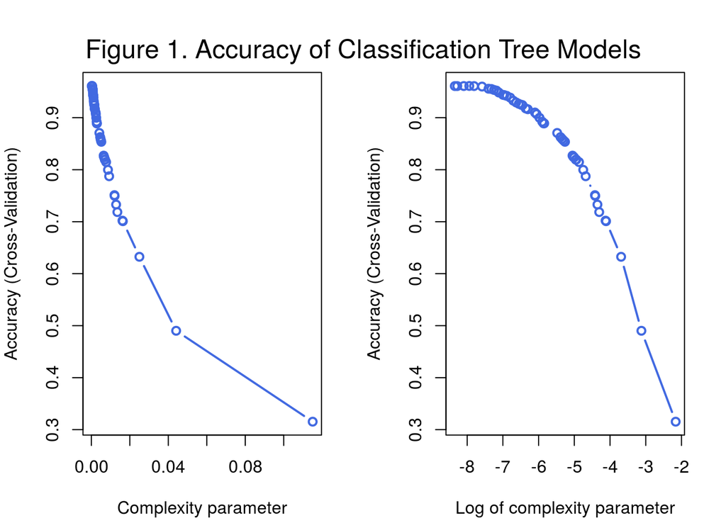

```r
par(mfrow=c(1,2), oma = c(0, 0, 3, 0), mar= c(4, 4, 0.5, 2))
plot(modelFitTree$results[,1], modelFitTree$results[,2], type="b", lwd=2,
     col="royalblue", xlab="Complexity parameter",
     ylab="Accuracy (Cross-Validation)")
plot(log(modelFitTree$results[,1]), modelFitTree$results[,2], type="b", lwd=2,
     col="royalblue", xlab="Log of complexity parameter",
     ylab="Accuracy (Cross-Validation)")
mtext("Figure 1. Accuracy of Classification Tree Models", outer=TRUE, cex = 1.5)
```

```r
library(rattle)
```

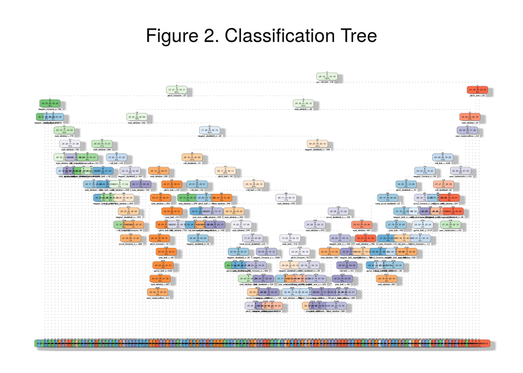

```r
par(mfrow=c(1,1), mar = c(2, 2, 0, 2), oma = c(0, 0, 3, 0))
fancyRpartPlot(modelFitTree$finalModel)
mtext("Figure 2. Classification Tree", outer=TRUE, cex = 1.5)
```

As shown in the left panel of Figure 1, the out-of-sample accuracy estimated by cross-validation was largest when the complexity parameter (cp) was small. The accuracy of the model seemed to level off at approx 0.96 (Figure one, right panel). The chosen model, with a complexity parameter of 3.56 × 10<sup>-4</sup> had an accuracy of 0.961 and estimated out-of-sample error rate of 0.039, and yielded a large and complex tree (Figure 2). It’s quite an accurate result, but can we do better?

I next fitted the data to random forest models, which build a number of decision trees on bootstrapped training samples. Each time a split in a tree is considered, a random sample of predictors is chosen as split candidates from the full set of predictors. Random forests are computationally much more intensive than classification trees, are less interpretable, but often yield more accurate results.

```r
set.seed(27)
modelFitRf <- train(classe ~ ., data=train, method="rf",
                 trControl = trainControl(method="cv", number=10))
modelFitRf
```

```
## Random Forest
##
## 13737 samples
##    54 predictors
##     5 classes: 'A', 'B', 'C', 'D', 'E'
##
## No pre-processing
## Resampling: Cross-Validated (10 fold)
##
## Summary of sample sizes: 12363, 12362, 12362, 12362, 12363, 12364, ...
##
## Resampling results across tuning parameters:
##
##   mtry  Accuracy  Kappa  Accuracy SD  Kappa SD
##    2    1         1      0.001        0.001
##   30    1         1      0.001        0.001
##   58    1         1      0.002        0.002
##
## Accuracy was used to select the optimal model using  the largest value.
## The final value used for the model was mtry = 30.
```

```r
# Best mtry
modelFitRf$bestTune
```

```
##   mtry
## 2   30
```

```r
# Accuracy
modelFitRf$results[2,2]
```

```
## [1] 0.9977
```

```r
# Out-of-sample error
1 - modelFitRf$results[2,2]
```

```
## [1] 0.002256
```

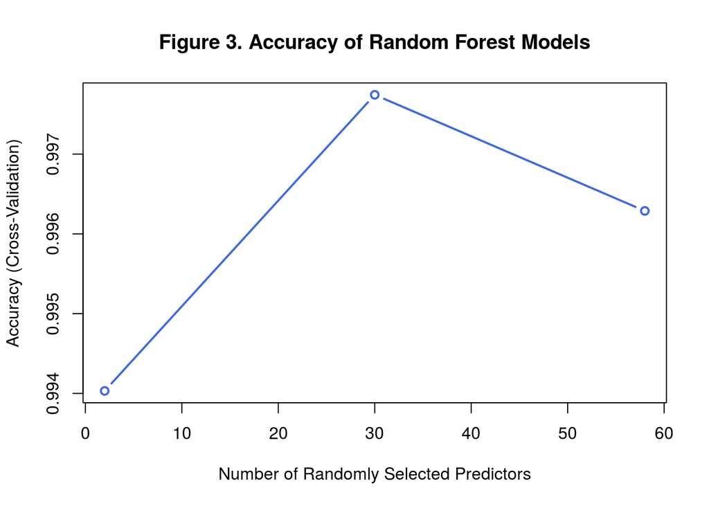

```r
par(old.par)
plot(modelFitRf$results[,1], modelFitRf$results[,2], type="b", lwd=2,
     col="royalblue", xlab="Number of Randomly Selected Predictors",
     ylab="Accuracy (Cross-Validation)",
     main= "Figure 3. Accuracy of Random Forest Models")
```

The cross-validated accuracy of the best model, with 30 variables randomly sampled as candidates at each split (mtry = 30), was 0.998 (Figure 3). This corresponds to an out-of-sample error rate of 0.002, and is an improvement compared to the error rate from the best classification tree.

Next, I validated the accuracy and error of the best random forest model using the test set I set aside from the whole dataset.

```r
pred <- predict(modelFitRf, test)
confMatrix <- table(pred, test$classe)
confMatrix
```

```
##
## pred    A    B    C    D    E
##    A 1673    1    0    0    0
##    B    1 1138    1    0    0
##    C    0    0 1025    4    0
##    D    0    0    0  960    2
##    E    0    0    0    0 1080
```

```r
error <- (1+1+1+4+2)/5885
accuracy <- 1 - error
error; accuracy
```

```
## [1] 0.001529
```

```
## [1] 0.9985
```

Using the best random forest model to predict the test set classes yielded in an error rate of 0.0015 and accuracy of 0.9985, which are very similar to the accuracy and error estimated by cross-validation.

The final goal of the analysis was to predict the exercise quality classes of 20 new observations. Because the best random forest model would yield one error for approx. 1 in 500 test observations, I considered this model accurate enough for making the final predictions. Each answer can be written to an individual text file with the code below.

```r
pred2 <- predict(modelFitRf, finalTesting)

answers <- as.vector(pred2)

# Function for writing each answer to an individual file.
pml_write_files = function(x){
  n = length(x)
  for(i in 1:n){
    filename = paste0("problem_id_",i,".txt")
    write.table(x[i], file=filename, quote=FALSE, row.names=FALSE,
                col.names=FALSE)
  }
}

#pml_write_files(answers)  #Uncomment to write files.
```

**References**

[1] Velloso, E.; Bulling, A.; Gellersen, H.; Ugulino, W.; Fuks, H. Qualitative Activity Recognition of Weight Lifting Exercises. Proceedings of 4th International Conference in Cooperation with SIGCHI (Augmented Human ’13). Stuttgart, Germany: ACM SIGCHI, 2013.